# Uso de IA, sueño y rendimiento académico en estudiantes de UTEC

PG2 | Grupo 6 | Estadística y Probabilidades, sección 01

Eduardo Raul Vila Castellares

Indira Shian Yabar Ramos

Johan Yadir Huayta Enriquez

Dervy Pillaca Pullo

Mathius Edgar Quispe Sicha

2026-11-13

## I–II. Introducción y contexto

### Tema y relevancia

**Uso de IA, sueño y rendimiento académico en estudiantes de UTEC.**

La inteligencia artificial generativa ya forma parte del estudio diario, y tanto el **sueño** como las **horas de estudio** influyen en el aprendizaje. Saber cómo se relacionan estos hábitos con la **comprensión** y la **satisfacción** ayuda a orientar mejores prácticas de estudio en UTEC.

### Objetivo general

**Analizar** el impacto de las horas de sueño y del uso de IA en el rendimiento académico de los estudiantes de Estadística, sección 01, ciclo 2026-2.

### Objetivos específicos

- **OE1: Analizar** la relación entre las consultas diarias a la IA y la satisfacción con el avance académico.
- **OE2: Analizar** la correlación entre las consultas a la IA y las horas de estudio.
- **OE3: Identificar** si el curso más consultado influye en el uso principal de la IA y qué usos ahorran más tareas.
- **OE4: Determinar** si las horas de sueño se relacionan con el nivel de comprensión.

### Datos y muestra efectiva

- **Población:** estudiantes UTEC de Estadística y Probabilidades, sección 01, 2026-2.
- **Unidad:** registro estudiante–día; se repiten mediciones por estudiante.
- **Muestreo:** sistemático por conveniencia, con diseño longitudinal.
- **Fuente:** formulario diario de Google Forms, al cierre del día (9:30 p. m.–medianoche).
- **Representatividad:** acceso diario a toda la sección y medición al cierre del día para reducir sesgo de memoria.
- **Muestra:** **674 registros** de 38 estudiantes. Grupo 6: **166**; se cumple el mínimo de 151.

### Variables

- **Discretas:** consultas y tareas con ahorro (enteros ≥ 0).
- **Continuas:** estudio (≥ 0 h) y sueño (0–24 h).
- **Ordinales:** satisfacción (Likert 1–5) y comprensión (muy bajo a muy alto).
- **Nominales:** uso principal de IA y curso (código XX####).

## III.1. Análisis descriptivo: análisis univariado

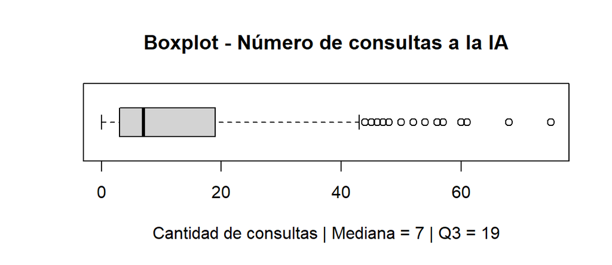

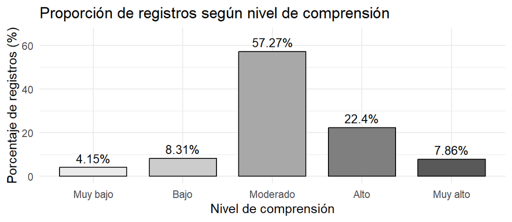

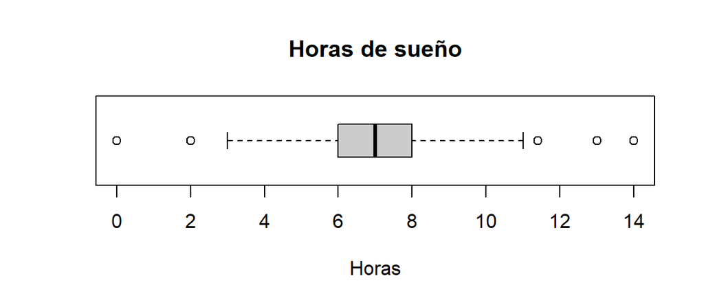

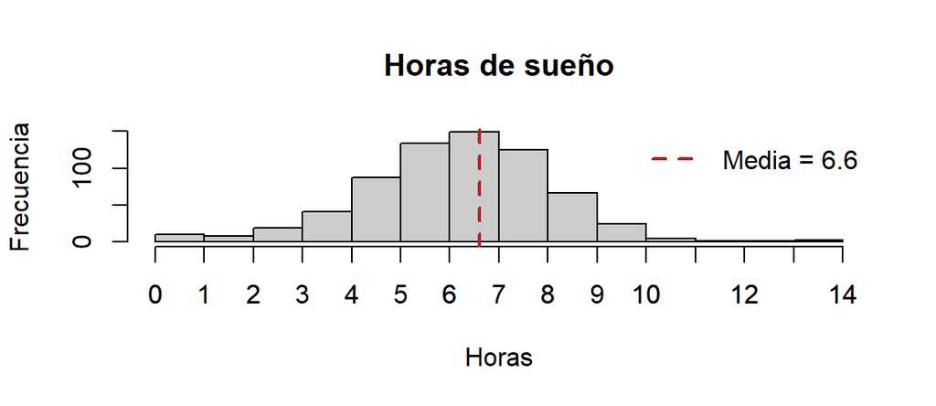

- **Número de consultas a la IA:** En al menos la mitad de los registros, el estudiante hace 7 o más consultas diarias a la IA, lo que indica un uso frecuente de esta herramienta.
- **Nivel de comprensión:** La moda y la mediana son Moderado.
- **Horas de sueño:** la mitad duerme 7 horas o menos, y el 50% central concentra su descanso entre las 6 y 8 horas.

## III. Análisis descriptivo: análisis de interacción

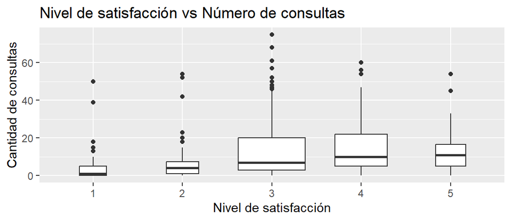

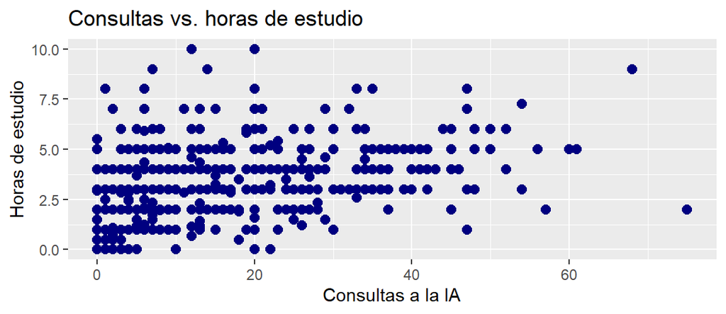

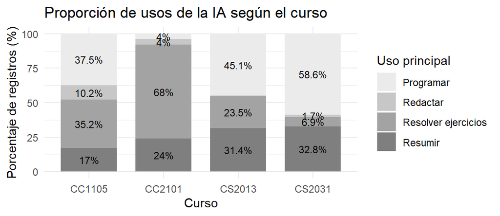

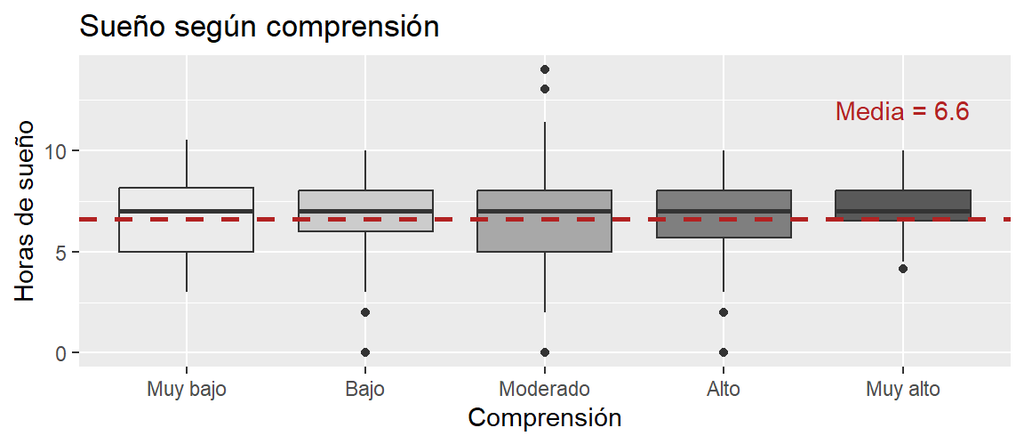

- **Objetivo 1:** Se nota un claro incremento en la mediana de `consultas` de acuerdo al incremento del nivel de satisfacción.
- **Objetivo 2:** hay una tendencia de que a mayor cantidad de horas de estudio habrá más consultas que se realizaron.
- **Objetivo 3a:** el uso de la IA cambia según el curso.
- **Objetivo 4:** No se observa una tendencia clara.

## IV.1 Probabilidad empírica

### Variable 1: consultas

**Experimento aleatorio:** seleccionar al azar un registro de la muestra efectiva y observar el nivel de uso de IA según el número de consultas realizadas ese día.

**Espacio de resultados:** $\Omega_{EA_1} = \{\text{Sin uso}, \text{Bajo}, \text{Moderado}, \text{Frecuente}, \text{Muy frecuente}\}$, donde Sin uso $= 0$, Bajo $= [1;10]$, Moderado $= [11;20]$, Frecuente $= [21;30]$ y Muy frecuente $= [31;+\infty\rangle$ consultas.

**Eventos atómicos:** $C_i$: seleccionar un registro al azar cuyo nivel de uso de IA sea el $i$-ésimo de $\Omega_{EA_1}$, con $i = 1, 2, 3, 4, 5$.

$P(C_1) =$ 0.0905; $P(C_2) =$ 0.5282; $P(C_3) =$ 0.1677; $P(C_4) =$ 0.0994; $P(C_5) =$ 0.1142.

**Validación:** $0.0905 + 0.5282 + 0.1677 + 0.0994 + 0.1142 = 1$

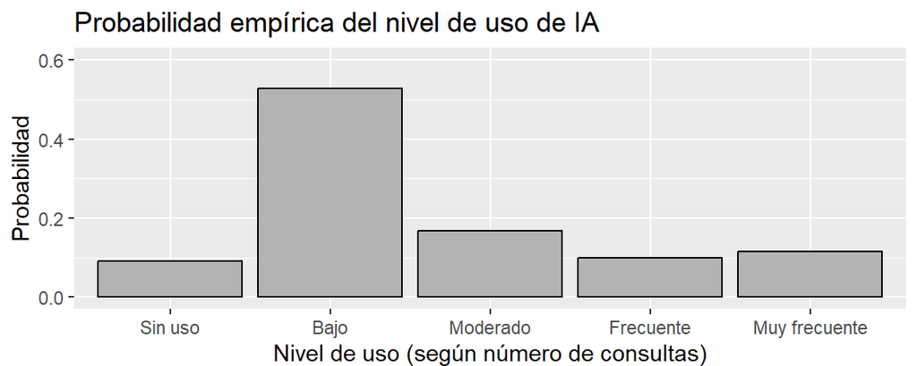

El nivel más probable es el bajo, con 0.5282. Las categorías moderado (0.1677), frecuente (0.0994) y muy frecuente (0.1142) se mantienen por debajo de 0.2, y sin uso tiene 0.0905, que corresponde a días sin ninguna consulta a la IA.

### Variable 2: satisfacción

**Experimento aleatorio:** seleccionar al azar un registro de la muestra efectiva y observar su nivel de satisfacción con el avance académico del día.

**Espacio de resultados:** $\Omega_{EA_2} = \{1, 2, 3, 4, 5\}$, donde 1 es muy baja y 5 muy alta.

**Eventos atómicos:** $S_i$: seleccionar un registro al azar cuyo nivel de satisfacción sea $i$, con $i = 1, 2, 3, 4, 5$.

$P(S_1) =$ 0.0727; $P(S_2) =$ 0.1053; $P(S_3) =$ 0.4525; $P(S_4) =$ 0.276; $P(S_5) =$ 0.0935.

**Validación:** $0.0727 + 0.1053 + 0.4525 + 0.276 + 0.0935 = 1$

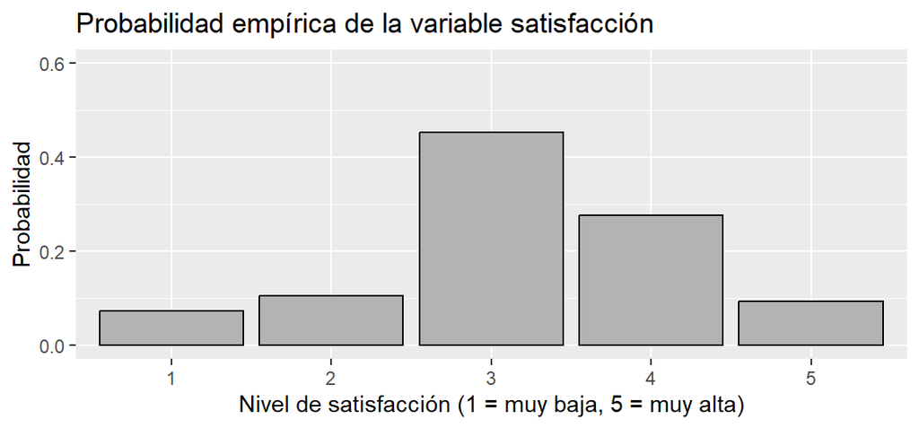

El nivel más probable es 3, con 0.4525. La probabilidad de una satisfacción alta (4 o 5) es 0.3694, casi el doble que la de una baja (1 o 2), que es 0.178.

## IV.2 Probabilidad condicional

### Eventos de interés

- **A:** registro con comprensión **Alto** → $P(A)=$ 0.224
- **B:** registro con **5 a 15 consultas** a la IA → $P(B)=$ 0.3769

Se eligió $[5,15]$ para evitar la alta concentración en $[0,5]$ y conservar suficientes datos.

Se analizará la probabilidad del evento A dado el evento B.

### Validación de independencia

#### Por medio de la intersección

$P(A\cap B)=$ 0.0801 $\neq$ $P(A)P(B)=$ 0.0844.

#### Por medio de la probabilidad condicional

$P(A|B)=$ 0.2126 $\neq P(A)=$ 0.224.

Los valores son diferentes en la muestra, pero la diferencia es pequeña y no prueba dependencia en toda la población.

### Propiedades

Procederemos a mostrar las propiedades de los eventos simples $A$ (nivel de comprensión `Alto`) y $B$ (consultas en $[5, 15]$), junto con sus eventos compuestos asociados y complementos.

- **Unión:** $P(A\cup B)=P(A)+P(B)-P(A\cap B)=$ 0.5208
- **Intersección:** $P(A\cap B)=$ 0.0801
- **Complementos:** $P(A^c)=$ 0.776 y $P(B^c)=$ 0.6231
- **De Morgan (unión):** $P((A\cup B)^c)=1-P(A\cup B)=$ 0.4792
- **De Morgan (intersección):** $P((A\cap B)^c)=1-P(A\cap B)=$ 0.9199
- **Diferencias:** $P(A\setminus B)=$ 0.1439; $P(B\setminus A)=$ 0.2967.
- **Diferencia simétrica:** $P(A\triangle B)=$ 0.4407.

El **52.08%** de los registros tiene comprensión alta, entre 5 y 15 consultas, o ambas.

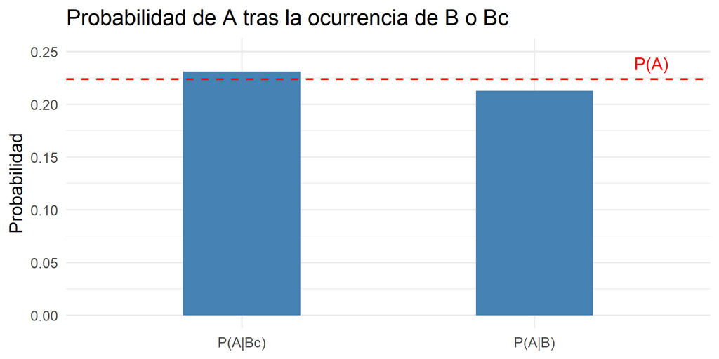

## IV.2 Teorema de Bayes e interpretación

### Teorema de Bayes

Aplicando el Teorema de Bayes para calcular la probabilidad del nivel de comprensión `Alto` ($A$) dado que las consultas están en el rango $[5, 15]$ ($B$):

$P(A|B) = \frac{P(B|A) \cdot P(A)}{P(B|A) \cdot P(A) + P(B|A^c) \cdot P(A^c)} =$ 0.2125984

$P(B|A)=$ 0.3576159; $P(B|A^c)=$ 0.3824092.

Aplicamos el Teorema de Bayes expandido:

$$P(A|B) = \frac{0.3576 \cdot 0.224}{0.3576 \cdot 0.224 + 0.3824 \cdot 0.776} = 0.2125984$$

Entonces, el valor obtenido es: **0.2125984**

Mientras que el resultado del cálculo directo fue: **0.2125984**

Los cálculos se realizaron adecuadamente, pues los resultados coinciden.

### Interpretación en el contexto del estudio

De los resultados del Teorema de Bayes se aprecia que la probabilidad de que el nivel de compresión sea `Alto` dado que la cantidad de consultas a la IA está en el intervalo [5, 15] es de 21.26%. Esto indicaría que es más probable obtener un nivel de comprensión distinto de `Alto` cuando se utiliza un número de consultas contenido en el rango [5, 15].

## IV.3 Variable aleatoria discreta: geométrica

**Caso:** Al revisar registros seleccionados al azar, uno tras otro y con reposición, ¿cuál es la probabilidad de que el primer éxito (É) sea el 5.º registro?

Éxito (É): más de 20 consultas a la IA. Fracaso (F): 20 o menos.

**Modelo**

- $X$: registros revisados hasta el primer éxito
- $X\sim Geom(p)$ con $p=\frac{144}{674}=0.2136$

**Eventos atómicos**

$\Omega=\{\text{É},\text{FÉ},\text{FFÉ},\text{FFFÉ},\text{FFFFÉ},\dots\}$ con $P(X=k)=(1-p)^{k-1}p$

| Propiedad | Modelo | Simulación |
| --- | --- | --- |
| E(X) = 1/p | 4.6806 | 4.8506 |
| Var(X) = (1-p)/p² | 17.2270 | 18.4329 |
| SD(X) = √Var(X) | 4.1505 | 4.2934 |

$P(X=5)=(1-0.2136)^4\cdot0.2136=0.0817\approx8.17\%$

$P(X\le5)=1-(1-0.2136)^5=0.6993\approx69.93\%$

Hay 8.17% de probabilidad de que el primer registro con más de 20 consultas sea el 5.º, y 69.93% de encontrarlo en 5 registros o menos.

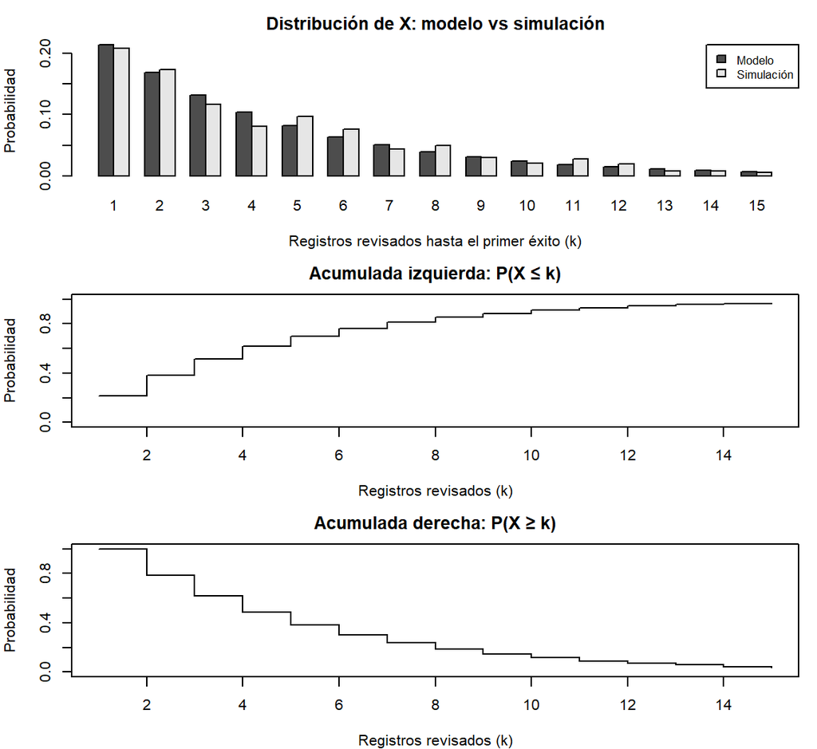

## IV.4 Variable aleatoria discreta: binomial

**Caso:** De 10 registros seleccionados al azar con reposición, ¿cuál es la probabilidad de que exactamente 3 sean éxito (É)?

Éxito (É): día con 3 o más tareas en las que la IA ahorró tiempo.

**Modelo**

- $X$: número de éxitos en 10 registros
- $X\sim Bin(10,p)$ con $p=\frac{150}{674}=0.2226$

**Eventos atómicos**

$\Omega=\{0,1,2,\dots,10\}$ con $P(X=k)=\binom{10}{k}p^k(1-p)^{10-k}$

| Propiedad | Modelo | Simulación |
| --- | --- | --- |
| E(X) = np | 2.2255 | 2.2060 |
| Var(X) = np(1-p) | 1.7302 | 1.6933 |
| SD(X) = √Var(X) | 1.3154 | 1.3013 |

$P(X=3)=\binom{10}{3}(0.2226)^3(1-0.2226)^7=0.2271\approx22.71\%$

$P(X<3)=P(X\le2)=0.6091\approx60.91\%$

Hay 22.71% de probabilidad de que exactamente 3 de los 10 registros sean éxito, y 60.91% de que sean menos de 3.

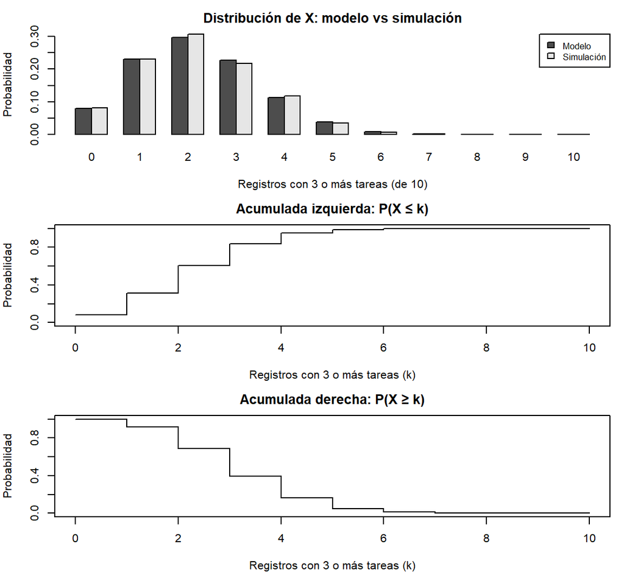

## IV.5 Variable aleatoria continua: normal

**Variable de estudio:** horas de sueño de la noche anterior.

**Modelo propuesto:** $X\sim N(\mu,\sigma)$, como aproximación.

**Validación:** la media (6.6 h) está cerca de la mediana (7 h), pero la simetría no es exacta. Se descartaron la exponencial y la uniforme para esta variable, como se explicó en el informe.

**Propiedades**

- $E(X)=\mu=$ 6.6 h.
- $Var(X)=\sigma^2=$ 3.791 h².
- $SD(X)=\sigma=$ 1.947 h.
- $CV=$ 29.5%.

**Ejemplo:** ¿cuál es la probabilidad de dormir 4 horas o menos?

- **Teórica:** $P(X\le 4)=$ 9.09%.
- **Empírica:** 11.57%.

La diferencia es de 2.49 puntos porcentuales. El modelo sirve como aproximación.

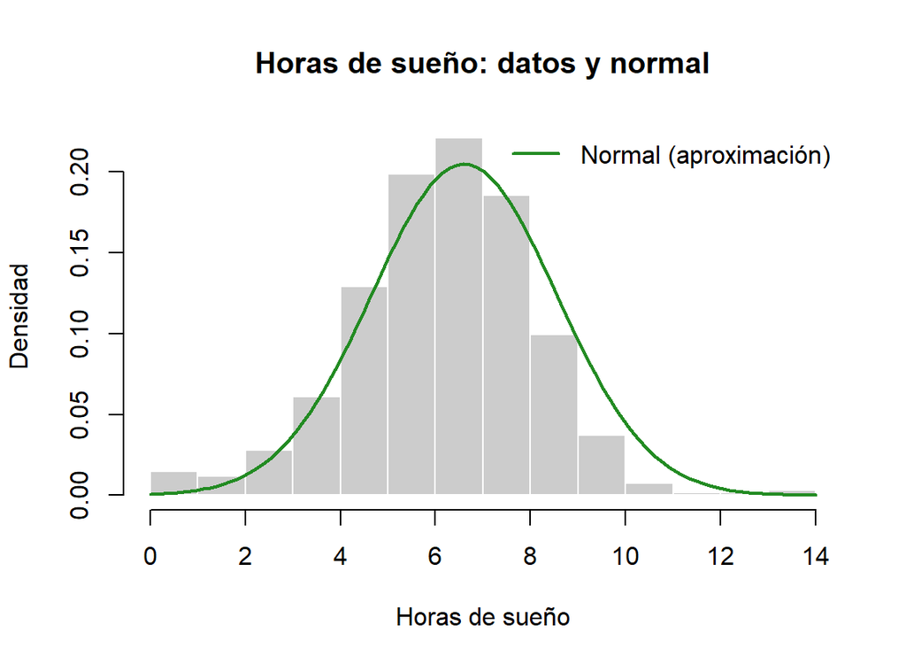

## IV.6 Variable aleatoria continua: exponencial

**Variable de estudio:** horas efectivas de estudio.

**Modelo propuesto:** $X\sim Exp(\lambda)$, como aproximación.

**Validación:** la variable es no negativa y la gráfica muestra más registros con pocas horas que con muchas. La varianza del modelo (8.349) no coincide con la muestral (3.373), por lo que el ajuste no es exacto.

**Propiedades**

- **Tasa:** $\lambda=1/\bar{x}=$ 0.346083 h⁻¹.
- $E(X)=1/\lambda=$ 2.889 h.
- $Var(X)=1/\lambda^2=$ 8.349 h².
- $SD(X)=1/\lambda=$ 2.889 h; $CV=1$.

**Ejemplo:** ¿cuál es la probabilidad de estudiar más de 5 y hasta 8 horas?

- **Teórica:** $P(5<X\le 8)=$ 11.45%.
- **Empírica:** 7.42%.

La diferencia es de 4.03 puntos porcentuales.

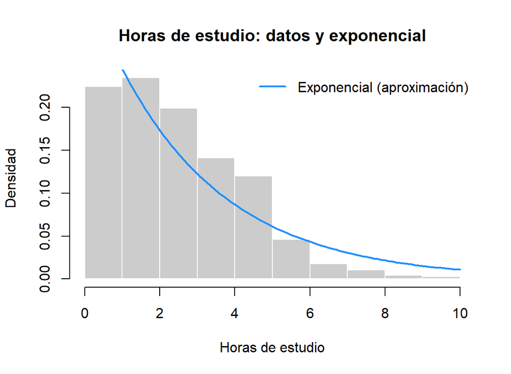

## V. Conclusiones

1. **Primera parte del estudio:** Después de limpiar los datos, vimos que los estudiantes de Estadística sección 1 usan la IA casi todos los días y para cosas distintas según el curso. Los que hacen más consultas suelen estudiar más horas y sentirse más satisfechos. Las horas de sueño casi no cambian según la comprensión.
2. **Probabilidad:** El 52.82% realiza entre 1 y 10 consultas diarias; el 45.25% reportó satisfacción de nivel 3. Entre quienes hicieron de 5 a 15 consultas, el 21.26% obtuvo comprensión Alto. Esto no asegura una comprensión alta.
3. **Variables aleatorias:** Al revisar 5 registros o menos con reposición, hay un 69.93% de probabilidad de encontrar uno con más de 20 consultas. La geométrica y la binomial se aplican a los casos planteados; la normal y la exponencial son aproximaciones de los datos.

**Alcance:** son 674 registros de 38 estudiantes, con mediciones repetidas. Las relaciones observadas no prueban que una variable cause la otra.